# Food web structures along the river-sea continuum

## Todo

- Species set difference and intersection between river and sea dataset
- Plot metaweb
- Plot local webs along the continuum
- Refine food web plots
- Add map with operations to local food web plot
- Diet category analysis along the continuum
- Add information to the metaweb (e.g. migratory status of species, invasive or native, freshwater, marine, estuarine, etc.)
- General information at the species level, such as, mean size, count, status, etc.
- Most common invasive species
- Location of invasive species
- **(blocked)** Structure metrics versus distance to river mouth

## Setup

```r
library(renv)
renv::load()
```

```
- The project is out-of-sync -- use `renv::status()` for details.
```

```r
library(targets)
library(here)
tar_config_set(
  store = here::here("_targets")
)
library(ggplot2)
library(dplyr)
library(sf)
devtools::load_all()
nice_theme()
```

## Species composition along the continuum

We start by looking at how much species overlap there is between the three surveys that make up the river-estuary-sea continuum: `river` (freshwater, ASPE), `nurse` (estuarine nursery grounds) and `pomet` (open coastal/sea).

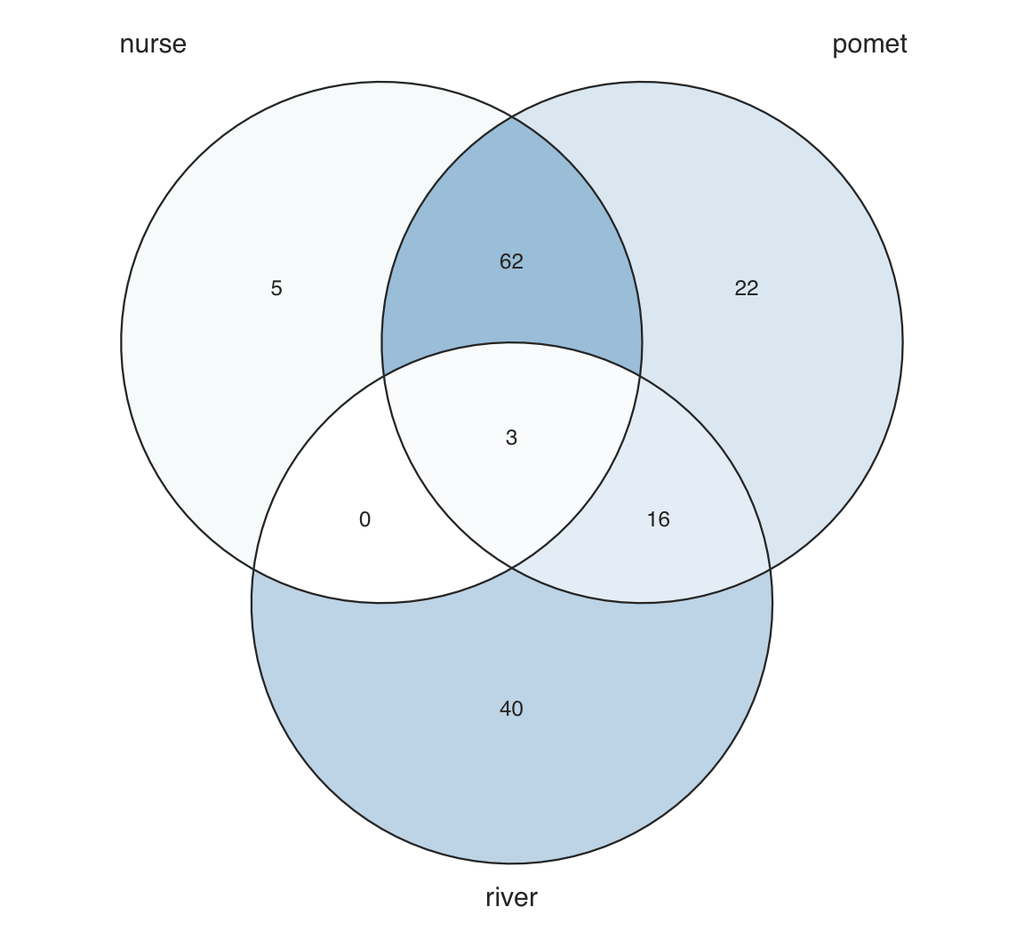

```r
size <- tar_read(size_year_filtered)
plot_venn_diagram(size)
```

Three species are shared by all three surveys: *Anguilla anguilla* (European eel, catadromous), *Chelon ramada* (grey mullet, euryhaline estuarine migrant) and *Platichthys flesus* (European flounder, catadromous flatfish).

More surprising is the `river`/`pomet` overlap (16 species), which excludes `nurse` entirely. These 16 are all strict freshwater residents (e.g. roach, bream, perch, pikeperch, barbel, chub, three-spined stickleback), not diadromous species. These species most probably come from `pomet` fishing operation that occurs deep into the estuaries (Girond and Loire).

So `river` and open sea share species through because of two reasons. First, through diadromous species that live across the whole continuum. Second, through residents caught by `pomet` operations deep into estuaries.

## Metaweb

The metaweb represents every possible predator-prey interaction across the whole continuum, aggregated over all size classes so each species appears as a single node. Species are placed vertically by trophic level, from basal resources (grey, bottom) up to fish (top), colored by whether they prey on other fish at any life stage, and sized by each species’ mean observed body length.

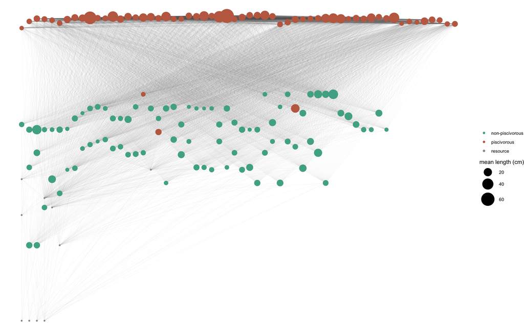

```r
web_list <- tar_read(web_list)
resource_list <- tar_read(resource_list)
diet <- tar_read(diet)
size <- tar_read(size_year_filtered)
plot_metaweb(web_list$metaweb, resource_list, diet, size)
```

148 fish species and 10 basal resources make up the metaweb, for a total of 8663 possible interactions at the species level.

The static plot above omits species labels for readability. For exploring individual species, here is the same network as an interactive plot: hover over a node to see its name, and zoom/pan to inspect dense areas. Fish nodes’ hover text also shows each species’ environment, migratory category and native/introduced status in France (see next section for where these come from and how missing values are handled).

```r
species_traits <- tar_read(species_traits)
plot_metaweb_interactive(
  web_list$metaweb,
  resource_list,
  diet,
  size,
  species_traits
)
```

[interactive chart not shown]

## Species-level information

```r
species_summary <- size |>
  group_by(species_valid) |>
  summarise(
    n_individuals = n(),
    n_operations = n_distinct(operation_id),
    mean_length = mean(length, na.rm = TRUE),
    .groups = "drop"
  ) |>
  left_join(species_traits, by = c("species_valid" = "species")) |>
  arrange(desc(n_individuals))
```

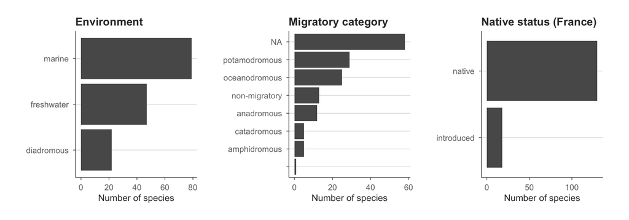

```r
count_bar <- function(data, var, title) {
  data |>
    count(.data[[var]]) |>
    mutate(val = forcats::fct_reorder(tidyr::replace_na(.data[[var]], "NA"), n)) |>
    ggplot(aes(n, val)) +
    geom_col() +
    labs(x = "Number of species", y = NULL, title = title)
}

patchwork::wrap_plots(
  count_bar(species_summary, "environment", "Environment"),
  count_bar(species_summary, "migratory_category", "Migratory category"),
  count_bar(species_summary, "native_status", "Native status (France)"),
  nrow = 1
)
```

The full species-level table: FishBase traits alongside observed count (number of individuals and operations) and mean length in the combined river-estuary-sea dataset.

```r
species_summary |>
  select(
    species = species_valid, environment, migratory_category, native_status,
    demers_pelag, n_individuals, n_operations, mean_length
  ) |>
  arrange(species) |>
  knitr::kable(digits = 1)
```

| species | environment | migratory_category | native_status | demers_pelag | n_individuals | n_operations | mean_length |
| --- | --- | --- | --- | --- | --- | --- | --- |
| Abramis brama | freshwater | potamodromous | native | benthopelagic | 13959 | 1454 | 12.0 |
| Agonus cataphractus | marine | NA | native | demersal | 200 | 62 | 5.0 |
| Alburnoides bipunctatus | freshwater | potamodromous | native | benthopelagic | 164626 | 2296 | 6.9 |
| Alburnus alburnus | freshwater | potamodromous | native | benthopelagic | 176158 | 3253 | 5.9 |
| Alosa alosa | diadromous | anadromous | native | pelagic-neritic | 27 | 22 | 10.6 |
| Alosa fallax | diadromous | anadromous | native | pelagic-neritic | 153 | 80 | 10.4 |
| Ambloplites rupestris | freshwater | NA | introduced | benthopelagic | 366 | 36 | 8.8 |
| Ameiurus melas | freshwater | amphidromous | introduced | demersal | 14860 | 754 | 11.0 |
| Ammodytes tobianus | marine | NA | native | demersal | 1077 | 236 | 12.0 |
| Anguilla anguilla | diadromous | catadromous | native | demersal | 79015 | 5094 | 33.3 |
| Aphia minuta | marine | oceanodromous | native | pelagic-neritic | 10130 | 596 | 5.3 |
| Argyrosomus regius | marine | oceanodromous | native | benthopelagic | 2524 | 346 | 14.9 |
| Arnoglossus laterna | marine | NA | native | demersal | 8868 | 849 | 8.6 |
| Arnoglossus thori | marine | NA | native | demersal | 200 | 100 | 9.1 |
| Atherina presbyter | marine | oceanodromous | native | pelagic-neritic | 3510 | 425 | 7.9 |
| Barbatula barbatula | freshwater | potamodromous | native | demersal | 429236 | 6302 | 6.8 |
| Barbus barbus | freshwater | potamodromous | native | benthopelagic | 87767 | 3006 | 10.0 |
| Barbus meridionalis | freshwater | NA | native | benthopelagic | 3956 | 252 | 8.6 |
| Blennius ocellaris | marine | NA | native | demersal | 16 | 11 | 9.3 |
| Blicca bjoerkna | freshwater | potamodromous | native | demersal | 28735 | 1708 | 8.9 |
| Buglossidium luteum | marine | NA | native | demersal | 22436 | 979 | 7.9 |
| Callionymus lyra | marine | NA | native | demersal | 34172 | 1732 | 9.8 |
| Carassius carassius | freshwater | potamodromous | introduced | demersal | 5336 | 790 | 13.3 |
| Chelidonichthys cuculus | marine | NA | native | demersal | 44 | 16 | 14.3 |
| Chelidonichthys lastoviza | marine | NA | native | demersal | 19 | 15 | 9.6 |
| Chelidonichthys lucerna | marine | NA | native | demersal | 747 | 405 | 12.8 |
| Chelon auratus | diadromous | catadromous | native | pelagic-neritic | 70 | 43 | 15.6 |
| Chelon labrosus | diadromous | catadromous | native | demersal | 49 | 12 | 7.6 |
| Chelon ramada | diadromous | catadromous | native | pelagic-neritic | 3694 | 466 | 17.1 |
| Chondrostoma nasus | freshwater | potamodromous | introduced | benthopelagic | 26823 | 1364 | 10.8 |

[output cut: 118 more lines]

## Local food webs along the continuum

To see how food web structure evolves along the continuum, we pick three individual operations along Gironde: one on the coast (`pomet`), one within the Gironde estuary itself (`nurse`), and one upstream on the Dordogne (`river`).

```r
foodweb_structure <- tar_read(foodweb_structure)
operation_year_filtered <- tar_read(operation_year_filtered)

ops <- c(
  pomet = "61832307", nurse = "2022_1_GIR12_14_S", river = "83544"
)
titles <- c(
  pomet = "Coast",
  nurse = "Estuary",
  river = "River"
)
```

First, a map showing where each of the three operations sits along the coastline/estuary/river.

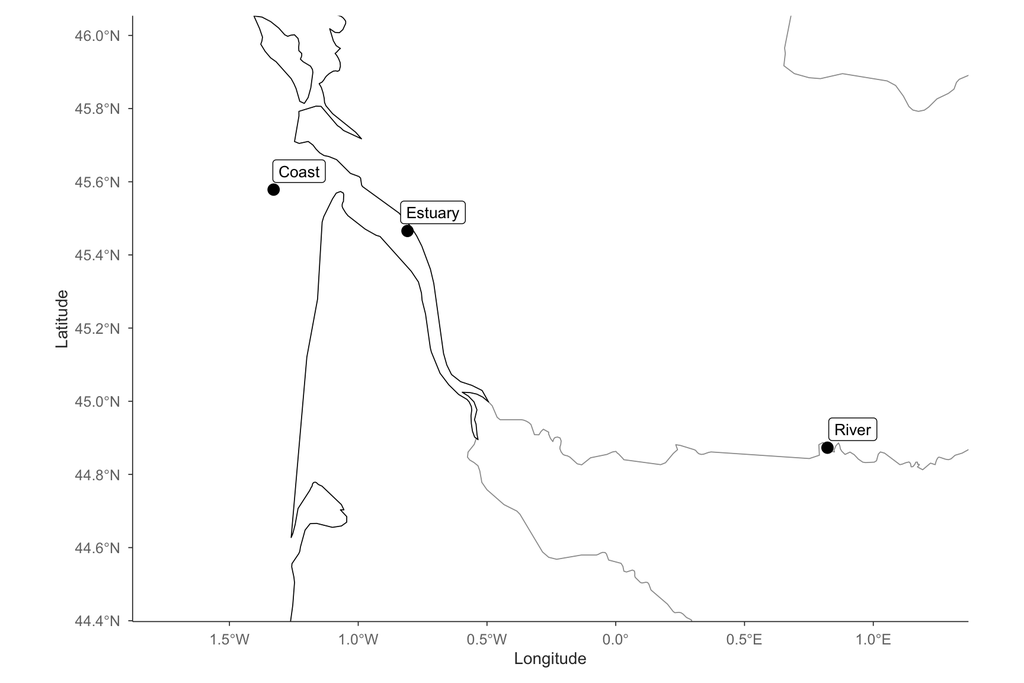

```r
continuum_pts <- operation_year_filtered |>
  filter(operation_id %in% ops) |>
  mutate(
    label = titles[names(ops)[match(operation_id, ops)]]
  )

france <- rnaturalearth::ne_countries(
  geounit = "france", type = "map_units", scale = "medium", returnclass = "sf"
)
rivers_fr <- rnaturalearth::ne_download(
  scale = 10,
  type = "rivers_lake_centerlines",
  category = "physical",
  returnclass = "sf"
) |>
  sf::st_intersection(france)

e <- 0.4
ggplot() +
  geom_sf(data = rivers_fr, color = "grey60", linewidth = 0.3) +
  geom_sf(data = coastline(), linewidth = 0.3) +
  geom_point(
    data = continuum_pts,
    aes(longitude, latitude),
    color = "black",
    size = 3
  ) +
  ggrepel::geom_label_repel(
    data = continuum_pts,
    aes(longitude, latitude, label = label),
    size = 3.5
  ) +
  coord_sf(
    xlim = range(continuum_pts$longitude) + c(-e, e),
    ylim = range(continuum_pts$latitude) + c(-e, e)
  ) +
  labs(x = "Longitude", y = "Latitude") +
  theme(
    plot.background = element_rect(fill = "white", color = NA),
    panel.background = element_rect(fill = "white", color = NA),
    panel.grid = element_blank()
  )
```

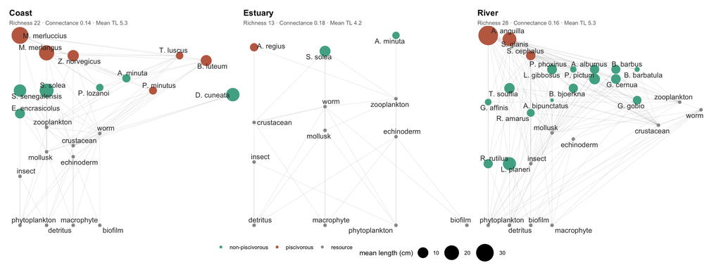

```r
# Shared size scale across all three panels, so `guides = "collect"` below
# merges them into a single legend instead of one per panel.
size_range <- (size |>
  filter(operation_id %in% ops) |>
  group_by(species_valid) |>
  summarise(v = mean(length, na.rm = TRUE), .groups = "drop"))$v |>
  range()

local_web_plots <- lapply(names(ops), function(nm) {
  fw_row <- foodweb_structure |> filter(operation_id == ops[nm])
  web <- fw_row$foodweb[[1]]
  op_size <- size |> filter(operation_id == ops[nm])
  subtitle <- sprintf(
    "Richness %d · Connectance %.2f · Mean TL %.1f",
    round(exp(fw_row$log_species_richness)), fw_row$connectance,
    fw_row$trophic_length
  )
  plot_local_foodweb(
    web, resource_list, diet, op_size,
    title = titles[nm], size_limits = size_range
  ) +
    labs(subtitle = subtitle) +
    theme(plot.subtitle = element_text(size = 9, color = "grey40"))
})

patchwork::wrap_plots(local_web_plots, nrow = 1) +
  patchwork::plot_layout(guides = "collect") &
  theme(legend.position = "bottom")
```

The three webs illustrate a clear shift in composition: the coastal web is built around marine flatfish and with several piscivorous predators; the estuarine web is sparser, dominated by basal resources with only a couple of connected fish; and the river web is dominated by small non-piscivorous cyprinids alongside a handful of large piscivorous predators.

## Structure metrics along the continuum

We look at trophic length, diet overlap, connectance and species richness. Diet overlap is the mean pairwise Jaccard similarity between predators’ prey sets (low = predators partition prey between them/complementarity, high = predators eat largely the same things/redundancy) - unlike connectance, it is close to independent of species richness (0.08 here vs. -0.63 for connectance), so it adds information richness alone doesn’t already give us.

```r
continuum_box <- foodweb_structure |>
  filter(longitude > -1.8, longitude < 1.3, latitude > 44.3, latitude < 46.0)

plot_metric_map <- function(data, metric, title) {
  ggplot(data) +
    geom_sf(
      data = rivers_fr, color = "grey70", linewidth = 0.3, inherit.aes = FALSE
    ) +
    geom_sf(data = coastline(), linewidth = 0.3, inherit.aes = FALSE) +
    geom_point(
      aes(longitude, latitude, color = .data[[metric]]), size = 1.8, alpha = 0.8
    ) +
    coord_sf(xlim = c(-1.8, 1.3), ylim = c(44.3, 46.0)) +
    scale_color_viridis_c() +
    labs(title = title, x = NULL, y = NULL, color = NULL) +
    theme(
      plot.background = element_rect(fill = "white", color = NA),
      panel.background = element_rect(fill = "white", color = NA),
      panel.grid = element_blank()
    )
}
```

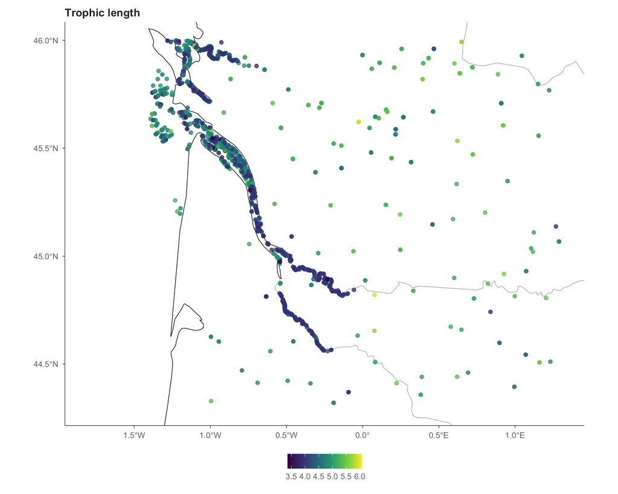

```r
plot_metric_map(continuum_box, "trophic_length", "Trophic length")
```

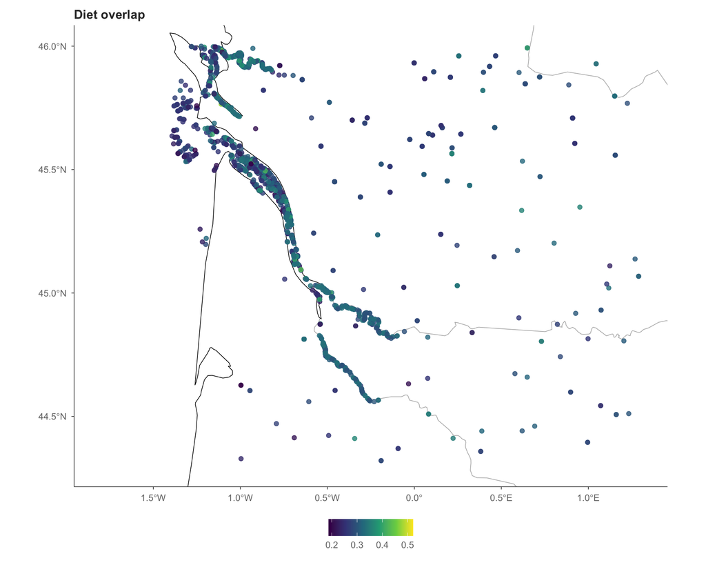

```r
plot_metric_map(continuum_box, "diet_overlap", "Diet overlap")
```

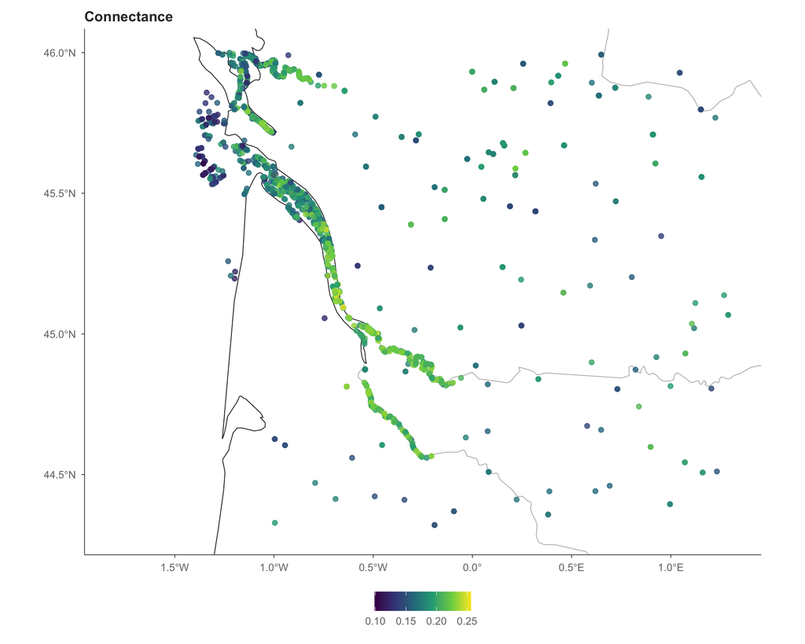

```r
plot_metric_map(continuum_box, "connectance", "Connectance")
```

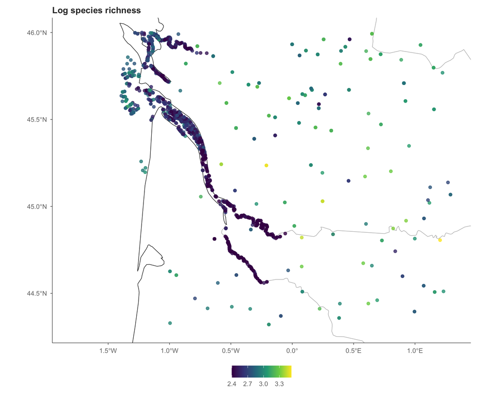

```r
plot_metric_map(continuum_box, "log_species_richness", "Log species richness")
```

## Diet composition by fish origin

We split species into three groups, reusing the same survey-membership logic as the venn diagram above: `freshwater` (found only in `river`), `marine` (found only in `nurse`/`pomet`), and `migratory` (found in both). For each group, we look at the average diet composition across resource categories (from the literature-curated diet table, not the constructed food webs), normalised so each group’s bars sum to 1.

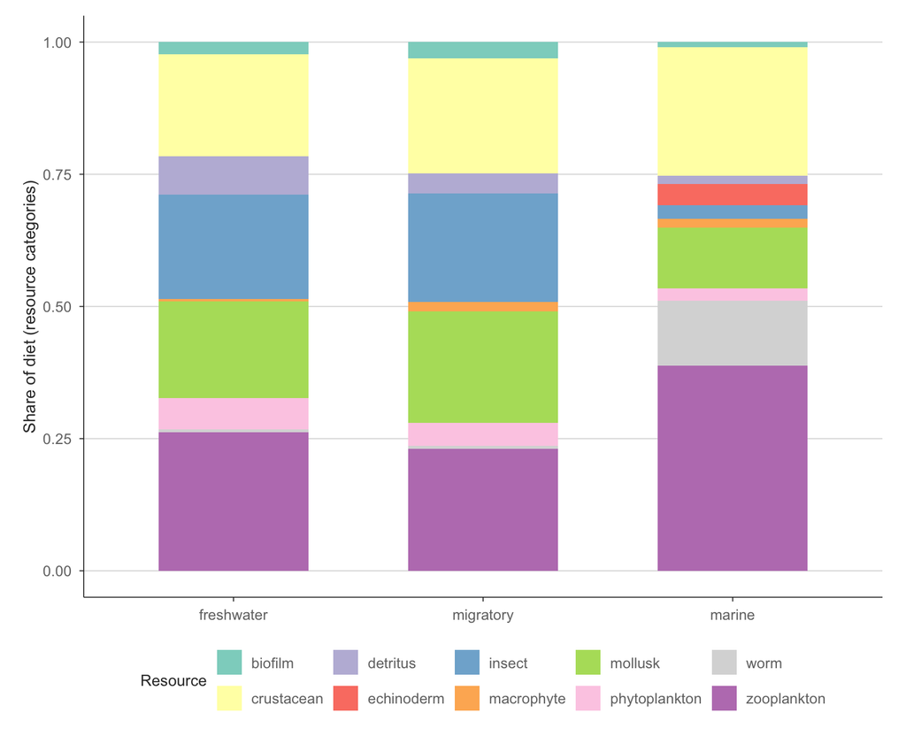

```r
species_origin <- size |>
  distinct(species_valid, survey) |>
  group_by(species_valid) |>
  summarise(
    surveys = paste(sort(unique(survey)), collapse = ","), .groups = "drop"
  ) |>
  mutate(
    has_river = grepl("river", surveys),
    has_marine = grepl("nurse|pomet", surveys),
    origin = case_when(
      has_river & !has_marine ~ "freshwater",
      !has_river & has_marine ~ "marine",
      has_river & has_marine ~ "migratory"
    )
  )

species_diet <- diet |>
  select(species, all_of(resource_list)) |>
  group_by(species) |>
  summarise(across(everything(), mean), .groups = "drop") |>
  inner_join(
    species_origin |> select(species_valid, origin),
    by = c("species" = "species_valid")
  )

origin_diet <- species_diet |>
  group_by(origin) |>
  summarise(across(all_of(resource_list), mean), .groups = "drop") |>
  tidyr::pivot_longer(
    -origin, names_to = "resource_cat", values_to = "value"
  ) |>
  group_by(origin) |>
  mutate(share = value / sum(value)) |>
  ungroup()

ggplot(
  origin_diet,
  aes(x = factor(origin, levels = c("freshwater", "migratory", "marine")),
      y = share, fill = resource_cat)
) +
  geom_col(width = 0.6) +
  scale_fill_brewer(palette = "Set3") +
  labs(x = NULL, y = "Share of diet (resource categories)", fill = "Resource")
```